# Home Alarm CLV

Prepare “Home Alarm, Inc.: Assessing Customer Lifetime Value” for class discussion and as an individual assignment and submit the assignment through GitLab. Be VERY clear about where results are coming from and what assumptions you are making in your R code. It is in your best interest that we do not have to struggle to figure out where your numbers came from. The assignment (pdf) is in the class Dropbox folder (week2/homealarm-ltv.pdf). Example R and Excel calculations are also on Dropbox (week1/readings).

## Setup

Create an rmarkdown document in which you calculate the CLV for a customers who uses auto-pay and for a customer that does not use auto-pay and answer question 1 through 4 in the assignment PDF.

## Analysis

The code chunk below sets the attrition notifications you should use in your analysis.

```r
## Attrition notifications
churn <- tibble::tibble(
  no_autopay = c(0.084, 0.122, 0.162, 0.154, 0.134, 0.120, 0.111, 0.096, 0.086),
  autopay = c(0.032, 0.070, 0.097, 0.103, 0.095, 0.078, 0.069, 0.059, 0.053)
)
```

Please generate an HTML (Notebook) with your answers to all the questions listed in the homealarm-clv.pdf file on Dropbox. When you have finished editing the Rmarkdown document and generated the HTML report make sure to save, commit, and push it to GitLab. We will collect all the rmarkdown files from GitLab after the due date.

> The CLV analysis begins on 1/1/Y2, since we’re looking for the value of the cohort who are about to start their 2nd year with Home Alarm for the next 8 years, 3.2% has already left us on 12/31/Y1 and the rest will be the whole 100% cohort we start analyzing “today” and they will stay with us the throughout year 2. The total number of years should be 8 years.

> Therefore, based on the assumption above, during the initial year, 100% of the cohort will be with the company. The company will be notice about their leaves at the end of each the year thereafter. Also, the company has a policy of collecting payment at the end of each month, which means we need to discount back the first payment as well.

### Part A - CLV analysis for auto-pay customers

```r
## Revenue
rmr <- 40
## Discount rate
annual_discount_rate <- 0.1
monthly_discount_rate <- (1 + annual_discount_rate)^(1 / 12) - 1
## Churn (auto-pay cohort)
annual_churn_auto <- c(0, churn$autopay[2:8])
retained_y2 <- 1 - annual_churn_auto[1]
retained_y3 <- retained_y2 - retained_y2 * annual_churn_auto[2]
retained_y4 <- retained_y3 - retained_y3 * annual_churn_auto[3]
retained_y5 <- retained_y4 - retained_y4 * annual_churn_auto[4]
retained_y6 <- retained_y5 - retained_y5 * annual_churn_auto[5]
retained_y7 <- retained_y6 - retained_y6 * annual_churn_auto[6]
retained_y8 <- retained_y7 - retained_y7 * annual_churn_auto[7]
retained_y9 <- retained_y8 - retained_y8 * annual_churn_auto[8]
## Variable cost
cost_service <- 0.15
marketing_cost <- 0.05
## Number of years
nr_years <- 8
## general increase
growth_rate <- 0.03
## variables to be used for CLV calculations
time <- 1:(nr_years * 12)
revenues <- c(rep(rmr, each = 12), rep(rmr * (1 + growth_rate), each = 12), rep(rmr * (1 + growth_rate)^2, each = 12), rep(rmr * (1 + growth_rate)^3, each = 12), rep(rmr * (1 + growth_rate)^4, each = 12), rep(rmr * (1 + growth_rate)^5, each = 12), rep(rmr * (1 + growth_rate)^6, each = 12), rep(rmr * (1 + growth_rate)^7, each = 12))
service <- cost_service * revenues
marketing <- marketing_cost * revenues
profit <- revenues - service - marketing
active <- c(rep(retained_y2, each = 12), rep(retained_y3, each = 12), rep(retained_y4, each = 12), rep(retained_y5, each = 12), rep(retained_y6, each = 12), rep(retained_y7, each = 12), rep(retained_y8, each = 12), rep(retained_y9, each = 12))
exp_profit <- active * profit
PV_exp_profit <- exp_profit / (1 + monthly_discount_rate)^time
## get the cumulated net present profit month by month
CLV <- cumsum(PV_exp_profit)
## make time and cumulated profit a dataframe: auto_pay
auto_pay <- tibble::tibble(time = time, CLV = CLV)
head(auto_pay)
```

```
# A tibble: 6 x 2
   time   CLV
  <int> <dbl>
1     1  31.7
2     2  63.2
3     3  94.5
4     4 125.
5     5 156.
6     6 187.
```

```r
tail(auto_pay)
```

```
# A tibble: 6 x 2
   time   CLV
  <int> <dbl>
1    91 1752.
2    92 1763.
3    93 1773.
4    94 1783.
5    95 1794.
6    96 1804.
```

**let’s take a look of how the aggregated value changes over time**

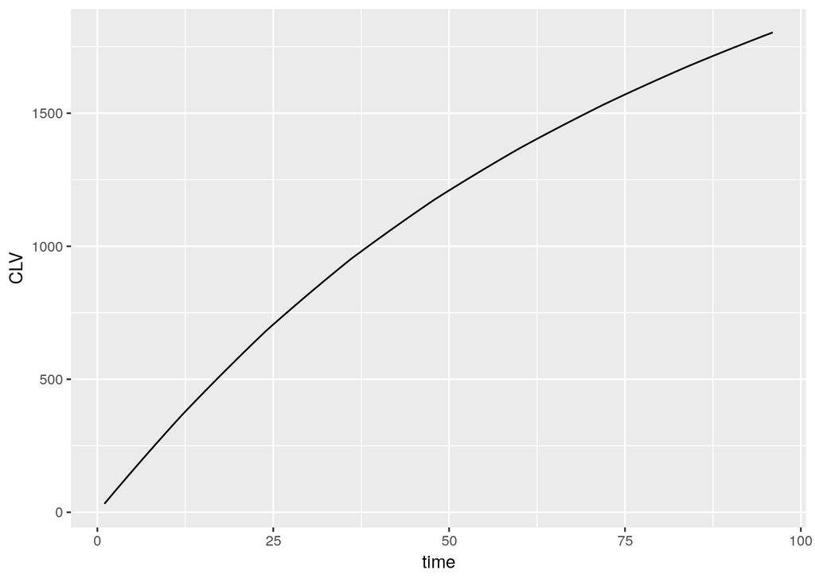

#### Q1

**The CLV column in auto_pay contains a customer’s accumulated value to the company aggregated by month, therefore, the last value, $1803.66, is a auto-pay customer’s CLV to the company.**

```r
(auto_clv <- auto_pay$CLV[96])
```

```
[1] 1803.66
```

### Part B - CLV analysis for non auto-pay customers

```r
annual_discount_rate <- 0.1
monthly_discount_rate <- (1 + annual_discount_rate)^(1 / 12) - 1
## Churn for non auto-pay customers
annual_churn_non <- c(0, churn$no_autopay[2:8])
## retain rate for non auto-pay customers
retained_y2 <- 1 - annual_churn_non[1]
retained_y3 <- retained_y2 - retained_y2 * annual_churn_non[2]
retained_y4 <- retained_y3 - retained_y3 * annual_churn_non[3]
retained_y5 <- retained_y4 - retained_y4 * annual_churn_non[4]
retained_y6 <- retained_y5 - retained_y5 * annual_churn_non[5]
retained_y7 <- retained_y6 - retained_y6 * annual_churn_non[6]
retained_y8 <- retained_y7 - retained_y7 * annual_churn_non[7]
retained_y9 <- retained_y8 - retained_y8 * annual_churn_non[8]
cost_service <- 0.15
marketing_cost <- 0.05
instal_charge <- 195
instal_cost <- 492
nr_years <- 8
growth_rate <- 0.03
time <- 1:(nr_years * 12)
revenues <- c(rep(rmr, each = 12), rep(rmr * (1 + growth_rate), each = 12), rep(rmr * (1 + growth_rate)^2, each = 12), rep(rmr * (1 + growth_rate)^3, each = 12), rep(rmr * (1 + growth_rate)^4, each = 12), rep(rmr * (1 + growth_rate)^5, each = 12), rep(rmr * (1 + growth_rate)^6, each = 12), rep(rmr * (1 + growth_rate)^7, each = 12))
service <- cost_service * revenues
marketing <- marketing_cost * revenues
profit <- revenues - service - marketing
active <- c(rep(retained_y2, each = 12), rep(retained_y3, each = 12), rep(retained_y4, each = 12), rep(retained_y5, each = 12), rep(retained_y6, each = 12), rep(retained_y7, each = 12), rep(retained_y8, each = 12), rep(retained_y9, each = 12))
exp_profit <- active * profit
PV_exp_profit <- exp_profit / (1 + monthly_discount_rate)^time
## Cumulated CLV by month for non auto-pay customers
CLV <- cumsum(PV_exp_profit)
```

#### Q2

```r
(noauto_clv <- CLV[96])
```

```
[1] 1553.723
```

#### Q3

**Let’s first get some feeling of how different an auto-pay customer could value to us from a non auto-pay customer over time**

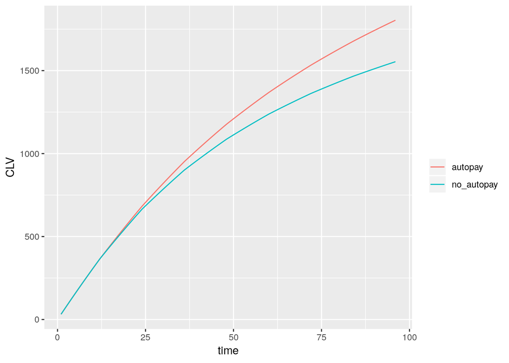

**The difference of the aggregated CLV between auto-pay and non auto-pay customer will be the theoratical maximum “effort” we would make to persuade the current non auto-pay customer to sign-up for auto-pay. Based on our calculation, this amount is $249.9**

```r
(diff <- auto_clv - noauto_clv)
```

```
[1] 249.9373
```

### Q4

> Based on the analysis, we know that the max monetary amount we could offer to convince an existing customer to convert to auto-pay is $249.9(NPV), assuming he will stay with us for at least the rest 8 years since the conversion. We therefore propose the following three incentive programs to Home Alarm for consideration:

### Solution One - Sign up Now and get half-year Free

**If current non auto-pay cohort switch to auto pay starting year 2, we’ll offer six months free service right away! However, for later opt-out or ending the contract completely, we’ll charge a minimum penalty of $200. The revised CLV from year 2 to year 9 under this promotion is $1616.9, lower than the existing auto-pay cohort CLV but still higher than current non auto-pay’s life time value.**

**The potential problem with this promotion is that it might hurt current auto-pay users who still need to pay at the normal rate. They could be so unhappy with our discrimination that choose to leave us the next year**

```r
## Revenue
rmr <- 40
rar <- 480
## Discount rate
annual_discount_rate <- 0.1
monthly_discount_rate <- (1 + annual_discount_rate)^(1 / 12) - 1
## Churn (auto-pay cohort)
annual_churn_auto <- c(0, churn$autopay[2:8])
retained_y2 <- 1 - annual_churn_auto[1]
retained_y3 <- retained_y2 - retained_y2 * annual_churn_auto[2]
retained_y4 <- retained_y3 - retained_y3 * annual_churn_auto[3]
retained_y5 <- retained_y4 - retained_y4 * annual_churn_auto[4]
retained_y6 <- retained_y5 - retained_y5 * annual_churn_auto[5]
retained_y7 <- retained_y6 - retained_y6 * annual_churn_auto[6]
retained_y8 <- retained_y7 - retained_y7 * annual_churn_auto[7]
retained_y9 <- retained_y8 - retained_y8 * annual_churn_auto[8]
## Variable cost
cost_service <- 0.15
marketing_cost <- 0.05
## Number of years
nr_years <- 8
## general increase
growth_rate <- 0.03
## variables to be used for CLV calculations
time <- 1:(nr_years * 12)
revenues <- c(0, 0, 0, 0, 0, 0, rep(rmr, each = 6), rep(rmr * (1 + growth_rate), each = 12), rep(rmr * (1 + growth_rate)^2, each = 12), rep(rmr * (1 + growth_rate)^3, each = 12), rep(rmr * (1 + growth_rate)^4, each = 12), rep(rmr * (1 + growth_rate)^5, each = 12), rep(rmr * (1 + growth_rate)^6, each = 12), rep(rmr * (1 + growth_rate)^7, each = 12))
service <- cost_service * revenues
marketing <- marketing_cost * revenues
profit <- revenues - service - marketing
active <- c(rep(retained_y2, each = 12), rep(retained_y3, each = 12), rep(retained_y4, each = 12), rep(retained_y5, each = 12), rep(retained_y6, each = 12), rep(retained_y7, each = 12), rep(retained_y8, each = 12), rep(retained_y9, each = 12))
exp_profit <- active * profit
PV_exp_profit <- exp_profit / (1 + monthly_discount_rate)^time

## CLV with Discount vs. regular auto-pay
sum(PV_exp_profit) - 1803.660
```

```
[1] -186.7531
```

### Solution Two - Step Cash Rebate

**The revised CLV under this plan for auto-pay cohort is $1583.658, lower than the current auto-pay cohort by $220 but still higher than do nothing. Compare to the first plan, this offer will probabaly has less negative effect on the existing auto-pay customer, but is also less appealing than the first one at the first sight, though it is more expensive. Moreover, to avoid people taking the money and ending the contract, we should add penalty term and make it clear to the customer that the cash rebate will be contingent on the long-term relationship with the company.**

```r
revenues <- c(rmr - 150, rep(rmr, each = 11), rep(rmr * (1 + growth_rate), each = 12), rep(rmr * (1 + growth_rate)^2, each = 11), rmr * (1 + growth_rate)^2 - 200, rep(rmr * (1 + growth_rate)^3, each = 12), rep(rmr * (1 + growth_rate)^4, each = 12), rep(rmr * (1 + growth_rate)^5, each = 12), rep(rmr * (1 + growth_rate)^6, each = 12), rep(rmr * (1 + growth_rate)^7, each = 12))
service <- cost_service * revenues
marketing <- marketing_cost * revenues
profit <- revenues - service - marketing
active <- c(rep(retained_y2, each = 12), rep(retained_y3, each = 12), rep(retained_y4, each = 12), rep(retained_y5, each = 12), rep(retained_y6, each = 12), rep(retained_y7, each = 12), rep(retained_y8, each = 12), rep(retained_y9, each = 12))
exp_profit <- active * profit
PV_exp_profit <- exp_profit / (1 + monthly_discount_rate)^time

## CLV with Discount vs. regular auto-pay
sum(PV_exp_profit) - 1803.660
```

```
[1] -220.0019
```

**However, the potential risk of this plan is that, people might get insensitive to the discounted monthly payment over time and choose to leave anyway just like regular non auto-pay customers, rendering the promotion ineffective; besides, once the promotion period ended, they might be relunctant to keep using our service at a higher though normal rate. Some of them may even start looking for better price in the market before the end of the program to get prepared for a new lower-priced service provider once it’s over.**

```r
## Revenue
rmr <- 40
rar <- 480
## Discount rate
annual_discount_rate <- 0.1
monthly_discount_rate <- (1 + annual_discount_rate)^(1 / 12) - 1
## Churn (auto-pay cohort)
annual_churn_auto <- c(0, churn$autopay[2:8])
retained_y2 <- 1 - annual_churn_auto[1]
retained_y3 <- retained_y2 - retained_y2 * annual_churn_auto[2]
retained_y4 <- retained_y3 - retained_y3 * annual_churn_auto[3]
retained_y5 <- retained_y4 - retained_y4 * annual_churn_auto[4]
retained_y6 <- retained_y5 - retained_y5 * annual_churn_auto[5]
retained_y7 <- retained_y6 - retained_y6 * annual_churn_auto[6]
retained_y8 <- retained_y7 - retained_y7 * annual_churn_auto[7]
retained_y9 <- retained_y8 - retained_y8 * annual_churn_auto[8]
## Variable cost
cost_service <- 0.15
marketing_cost <- 0.05
## Number of years
nr_years <- 8
## general increase
growth_rate <- 0.03
## variables to be used for CLV calculations
time <- 1:(nr_years * 12)
revenues <- c(rep(rmr * 0.85, each = 12), rep(rmr * 0.85 * (1 + growth_rate), each = 12), rep(rmr * 0.85 * (1 + growth_rate)^2, each = 12), rep(0.85 * rmr * (1 + growth_rate)^3, each = 12), rep(0.85 * rmr * (1 + growth_rate)^4, each = 12), rep(0.85 * rmr * (1 + growth_rate)^5, each = 12), rep(rmr * (1 + growth_rate)^6, each = 12), rep(rmr * (1 + growth_rate)^7, each = 12))
service <- cost_service * revenues
marketing <- marketing_cost * revenues
profit <- revenues - service - marketing
active <- c(rep(retained_y2, each = 12), rep(retained_y3, each = 12), rep(retained_y4, each = 12), rep(retained_y5, each = 12), rep(retained_y6, each = 12), rep(retained_y7, each = 12), rep(retained_y8, each = 12), rep(retained_y9, each = 12))
exp_profit <- active * profit
PV_exp_profit <- exp_profit / (1 + monthly_discount_rate)^time

## CLV with Discount vs. regular auto-pay
sum(PV_exp_profit) - 1803.660
```

```
[1] -229.9475
```